# Entrega 2: LIMPIEZA GENERAL

Curso: POL304 - Estadística para el análisis político 2

Joel B. Hu y Fabian Rios

2022-10-07

# Limpieza de las bases de datos escogidas

- El objetivo de esta segunda entrega es descartar las variables independientes que no influyan en la variable dependiente (`Desempleo juvenil`).
- Para ello, importaremos las bases de datos escogidas, luego procederemos con la limpieza, después unificaremos las variables en una sola data y, finalmente, realizaremos las pruebas estadísticas correspondientes con la regresión lineal múltiple.
  - tanova y diagnosticos de regresion

# Variables de José

### Importamos:

```r
library(rio)
desempleo_df = import("https://github.com/luccemhu/TRABAJO-GRUPAL-ESTADISTICA-2/raw/main/dfs_E2/desempleoBM.csv")
#head(desempleo_df)
```

### Formateo:

```r
desempleo_df = desempleo_df[-c(1:4, 6, 8),] # Borrando filas determinadas

library(dplyr)
desempleojuve <- desempleo_df |>
  select('Data Source', '_60') |> # Seleccionando pais y Year
  na.omit() # Borrando NAs

# Renombrando las columnas seleccionadas
colnames(desempleojuve) = c("pais", "desempleo")
```

## Variable independiente: Obesidad en adultos

### Importamos:

```r
obeadult_df = import("https://github.com/luccemhu/TRABAJO-GRUPAL-ESTADISTICA-2/raw/main/dfs_E2/ObesidadCIA.csv")
#head(obeadult_df)
```

### Formateo:

```r
obesidad <- obeadult_df |>
  select("name", "value") |> # Seleccionando pais y Year
  na.omit() # Borrando NAs

#Renombrando las columnas seleccionadas:
colnames(obesidad) = c("pais", "obeadult")
```

## Variable independiente: Infraestructura de tránsito

### Importamos:

```r
inftransito_df = import("https://github.com/luccemhu/TRABAJO-GRUPAL-ESTADISTICA-2/raw/main/dfs_E2/RoadW.csv")
#head(dataobeadult)
```

### Formateo:

```r
transito <- inftransito_df |>
  select("name", "value") |> # Seleccionando pais y Year
  na.omit() # Borrando NAs

#Renombrando las columnas seleccionadas:
colnames(transito) = c("pais", "inftransito")
```

## Variable independiente: Gastos en educación

### Importamos:

```r
gastoseduc_df = import("https://github.com/luccemhu/TRABAJO-GRUPAL-ESTADISTICA-2/raw/main/dfs_E2/GastosEdu.csv")
#head(gastoseduc)
```

### Formateo:

```r
gastos <- gastoseduc_df |>
  select("name", "value") |> # Seleccionando pais y Year
  na.omit() # Borrando NAs
# Renombrando las columnas seleccionadas:
colnames(gastos) = c("pais", "gastoseduc")
```

## Variable independiente: Libertad civica

- *Esta variable fue descartada*

### Importamos:

```r
library(htmltab) # Instalar remotamente:
#install.packages("remotes")
#remotes::install_github("htmltab/htmltab")
library(readr)
library(stringr)

WhereDEMO = list(page = "https://en.wikipedia.org/wiki/Democracy_Index",
                 xpath = '//*[@id="mw-content-text"]/div[1]/table[6]/tbody')
LiCiv  = htmltab(doc = WhereDEMO$page,
                 which  = WhereDEMO$xpath,
                 encoding = "UTF-8")
```

### Formateo:

```r
LiCiv$`Rank >> Full democracies >> Flawed democracies >> Hybrid regimes >> Authoritarian regimes` <-
  NULL
LiCiv$`Electoral processand pluralism >> Full democracies >> Flawed democracies >> Hybrid regimes >> Authoritarian regimes` <-
  NULL
LiCiv$`Functioningof government >> Full democracies >> Flawed democracies >> Hybrid regimes >> Authoritarian regimes` <-
  NULL
LiCiv$`Politicalparticipation >> Full democracies >> Flawed democracies >> Hybrid regimes >> Authoritarian regimes` <-
  NULL
LiCiv$`Politicalculture >> Full democracies >> Flawed democracies >> Hybrid regimes >> Authoritarian regimes` <-
  NULL
LiCiv$`.mw-parser-output .tooltip-dotted{border-bottom:1px dotted;cursor:help}Δ Rank >> Full democracies >> Flawed democracies >> Hybrid regimes >> Authoritarian regimes` <-
  NULL
LiCiv$`Δ Score >> Full democracies >> Flawed democracies >> Hybrid regimes >> Authoritarian regimes` <-
  NULL
LiCiv$`Overall score >> Full democracies >> Flawed democracies >> Hybrid regimes >> Authoritarian regimes` <-
  NULL
LiCiv$`Regime type >> Full democracies >> Flawed democracies >> Hybrid regimes >> Authoritarian regimes` <-
  NULL
LiCiv$name = LiCiv$`Country >> Full democracies >> Flawed democracies >> Hybrid regimes >> Authoritarian regimes`
LiCiv$`Country >> Full democracies >> Flawed democracies >> Hybrid regimes >> Authoritarian regimes` <-
  NULL
LiCiv$LibertadCivil = LiCiv$`Civilliberties >> Full democracies >> Flawed democracies >> Hybrid regimes >> Authoritarian regimes`
LiCiv$`Civilliberties >> Full democracies >> Flawed democracies >> Hybrid regimes >> Authoritarian regimes` <-
  NULL
LiCiv$LibertadCivil <- as.numeric(LiCiv$LibertadCivil)
```

```r
LiCiv$name = trimws(LiCiv$name, which = c("left"), whitespace = "[\\h\\v]")
#head(LiCiv)

LiCiv = na.omit(LiCiv) # Borrando NAs
colnames(LiCiv) = c("pais", "libertadci")
```

# Hipótesis y regresión

- Consideramos, de nuevo, que el desempleo juvenil se puede explicar por los gastos en educacion que permiten una especializacion, los kilometros de carreteras pavimentadas y no pavimentadas que permiten la extension de area de trabajo, la libertad civil y la obesidad del individuo que puede afectar a los trabajos fisicos. Esto hace que se realice una regresion adecuada, en este caso la lineal para ver si se puede ver la influencia del gasto en la educacion, los kilometros de carreteras, la obesidad en los adultos y la libertad civil a nivel global.

## Unificamos las variables para realizar la regresión:

```r
df_1 = merge(desempleojuve, obesidad, by = "pais")
df_2 = merge(transito, gastos, by = "pais")
df_3 = merge(df_2, LiCiv, by = "pais")

df_jose = merge(df_1, df_3, by = "pais")
```

```r
Modelo1 = lm(desempleo ~ gastoseduc + inftransito + obeadult + libertadci, data = df_jose)
summary(Modelo1)
```

```
##
## Call:
## lm(formula = desempleo ~ gastoseduc + inftransito + obeadult +
##     libertadci, data = df_jose)
##
## Residuals:
##    Min     1Q Median     3Q    Max
## -8.720 -3.186 -1.687  1.194 20.066
##
## Coefficients:
##               Estimate Std. Error t value Pr(>|t|)
## (Intercept)  3.589e+00  1.523e+00   2.356   0.0199 *
## gastoseduc   2.216e-01  3.113e-01   0.712   0.4778
## inftransito  4.734e-08  6.337e-07   0.075   0.9406
## obeadult     1.298e-01  5.735e-02   2.263   0.0253 *
## libertadci  -6.728e-03  1.978e-01  -0.034   0.9729
## ---
## Signif. codes:  0 '***' 0.001 '**' 0.01 '*' 0.05 '.' 0.1 ' ' 1
##
## Residual standard error: 5.378 on 130 degrees of freedom
## Multiple R-squared:  0.05556,    Adjusted R-squared:  0.0265
## F-statistic: 1.912 on 4 and 130 DF,  p-value: 0.1122
```

## Diagnosticamos la regresion antes de llegar a una conclusion de la hipotesis.

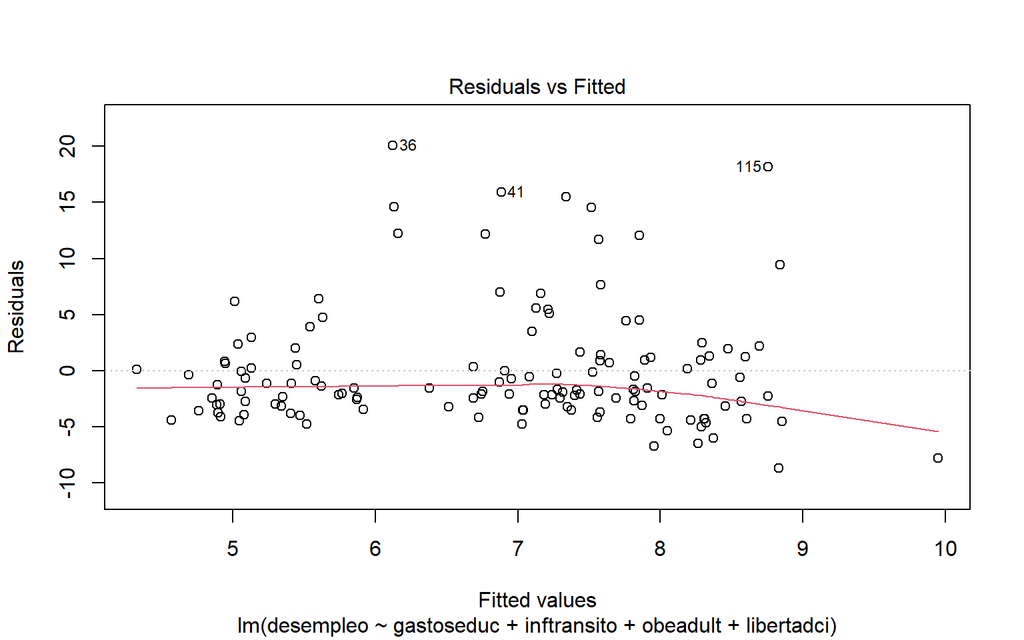

```r
plot(Modelo1, 1)
```

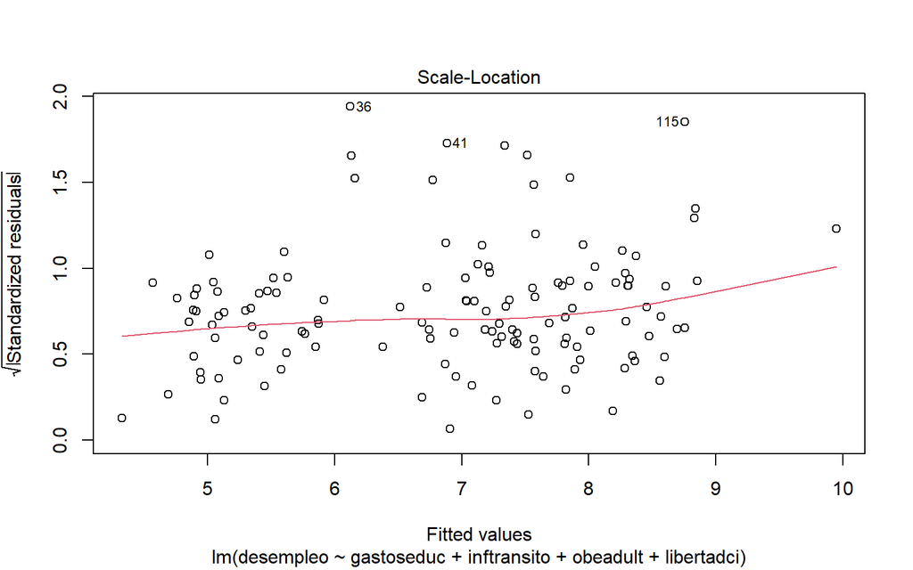

```r
plot(Modelo1, 3)
```

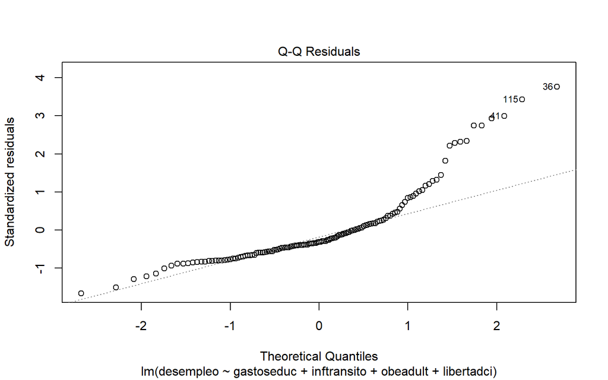

```r
plot(Modelo1, 2)
```